29%

32%

22%

19%

75%

43%

11%

5%

5%

38%

22%

Period above threshold

period above 10

−17%

−40%

37%

35%

34%

46%

42%

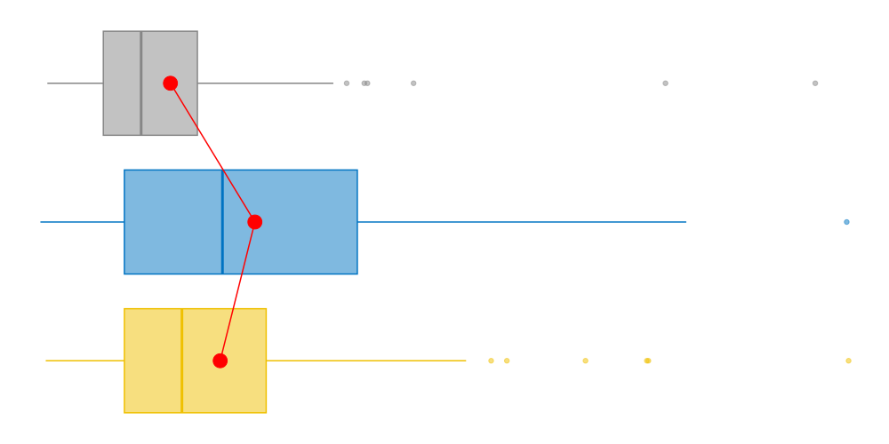

18%

16%

15%

28%

23%

Timing above threshold

first timing above 250

−2%

−5%

4%

3%

1%

17%

9%

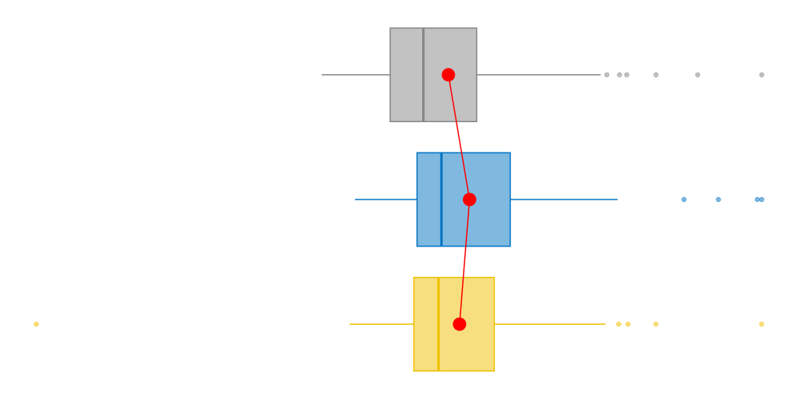

4%

2%

0%

73%

21%

Timing above threshold

first timing above 1000

−1%

−3%

4%

4%

1%

18%

8%

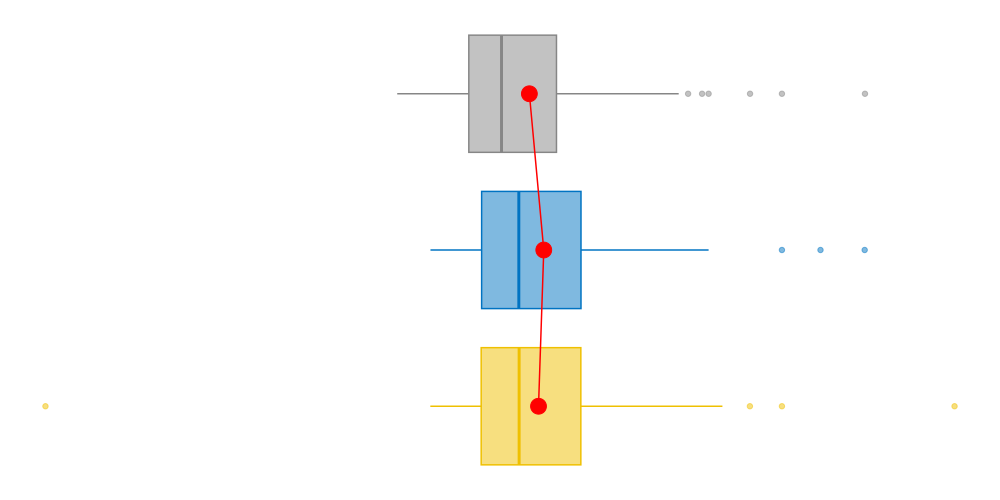

3%

5%

0%

75%

17%

Timing above threshold

last timing above 10

2%

5%

7%

3%

4%

3%

8%

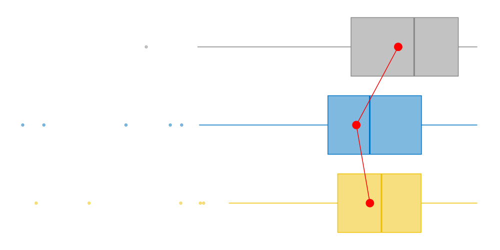

33%

5%

12%

6%

45%

Timing above threshold

last timing above 250

3%

4%

9%

3%

2%

9%

9%

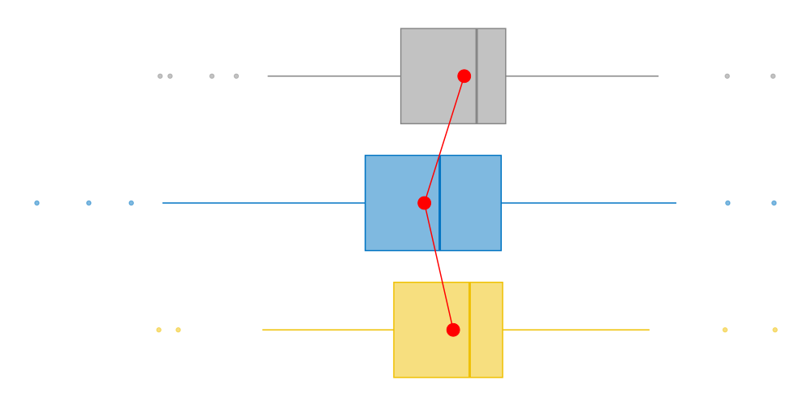

34%

4%

2%

29%

31%

Pulses above threshold

total duration pulses above 1000

17%

16%

31%

25%

10%

85%

36%

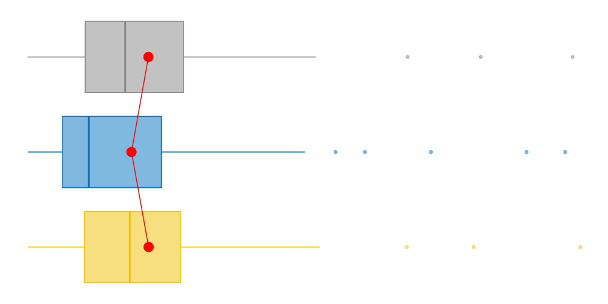

9%

6%

1%

71%

13%

Time above threshold

duration above 1000

13%

20%

39%

23%

8%

94%

44%

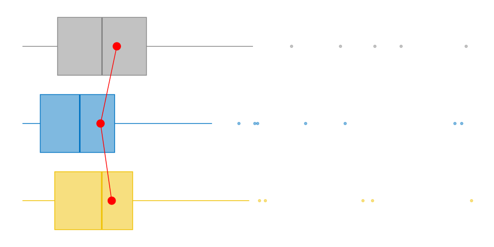

12%

4%

0%

69%

15%

Pulses above threshold

n pulses above 1000

17%

26%

34%

18%

30%

81%

45%

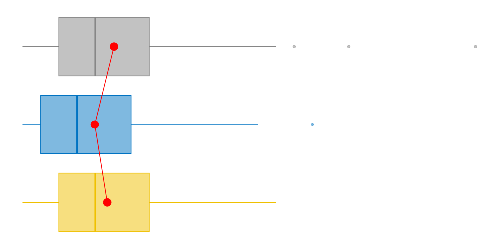

10%

3%

8%

59%

19%

M5

darkest 5h midpoint

15%

32%

41%

43%

10%

84%

99%

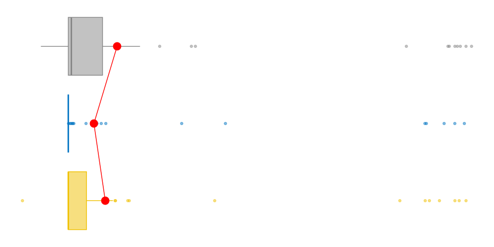

8%

9%

0%

34%

48%

Disparity index

disparity index

9%

59%

31%

29%

47%

34%

34%

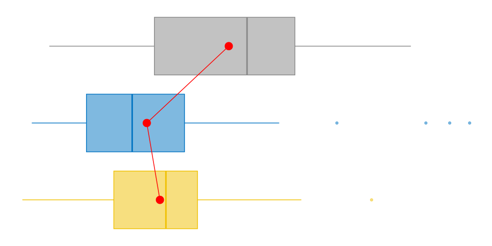

15%

13%

35%

18%

18%

Pulses above threshold

n pulses above 250

14%

57%

40%

1%

28%

71%

65%

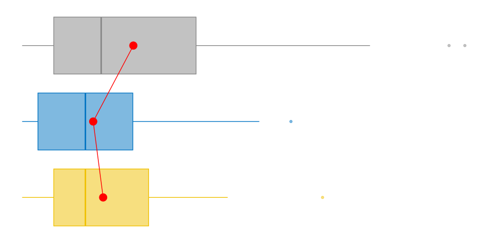

14%

0%

7%

43%

37%

Frequency crossing threshold

frequency crossing 250

7%

66%

39%

22%

46%

80%

74%

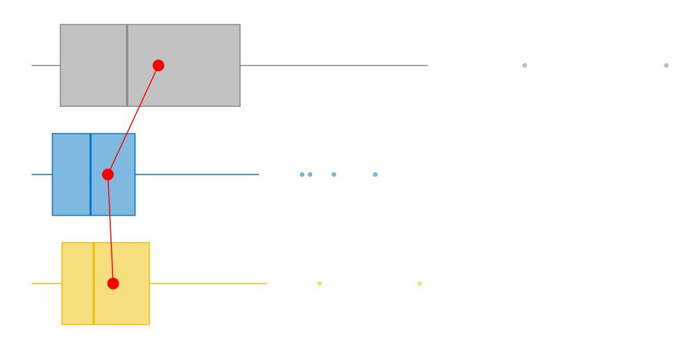

9%

3%

13%

40%

35%

Mean (log) mel EDI

mean MEDI

26%

50%

143%

68%

40%

140%

92%

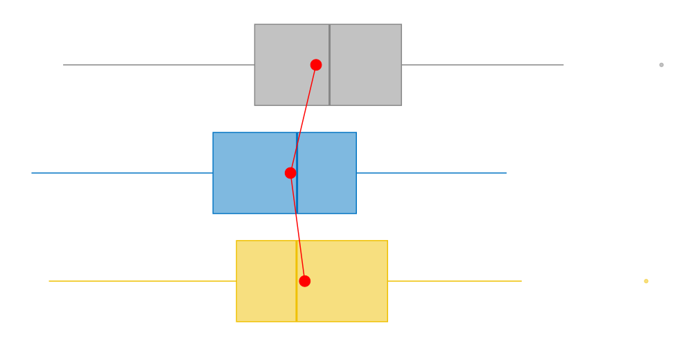

37%

8%

3%

36%

15%

M5

darkest 5h onset

62%

206%

0%

118%

158%

263%

346%

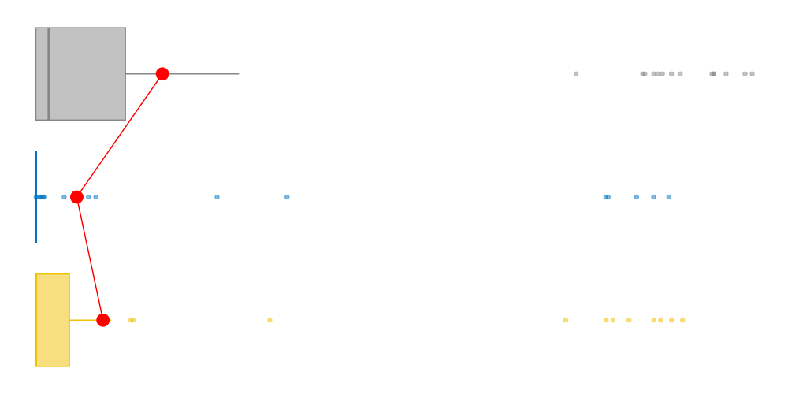

0%

6%

11%

30%

53%

Both differ significantly from head position:

Median (abs)

5%

4%

1%

5%

5%

12%

8%

0%

8%

8%

56%

27%

Timing above threshold

first timing above 10

−14%

−31%

0%

16%

18%

—

36%

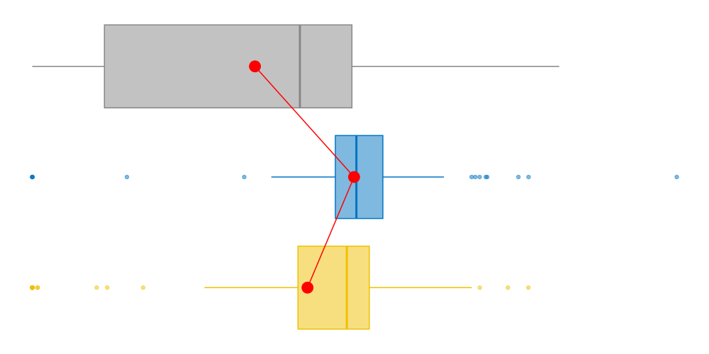

0%

14%

18%

—

68%

Barroso

dark cluster

−12%

−32%

18%

15%

6%

16%

22%

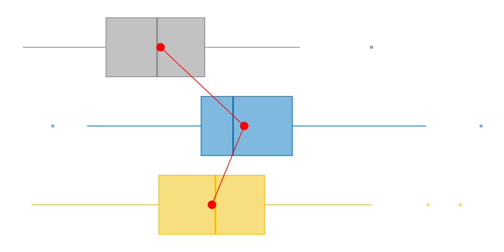

24%

17%

2%

19%

37%

Timing above threshold

mean timing above 250

3%

3%

0%

3%

4%

11%

6%

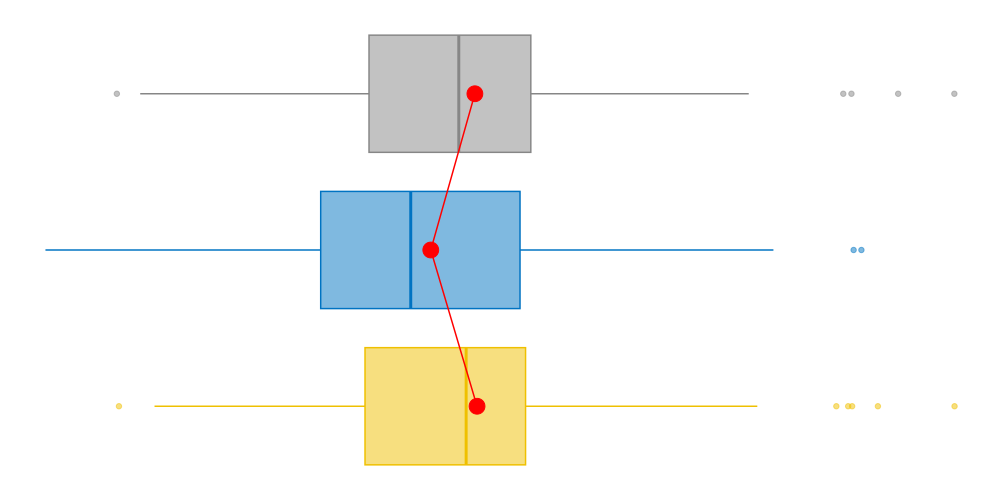

0%

5%

7%

69%

19%

Pulses above threshold

mean offset pulses above 250

4%

4%

0%

4%

4%

12%

8%

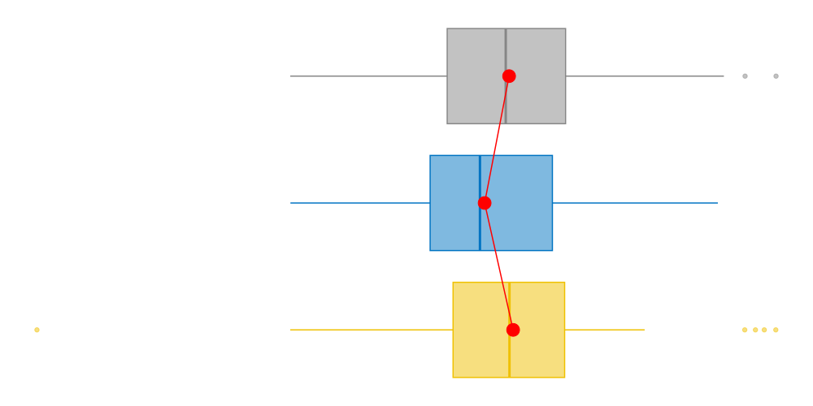

0%

7%

7%

58%

28%

Pulses above threshold

mean midpoint pulses above 250

4%

4%

1%

5%

5%

12%

8%

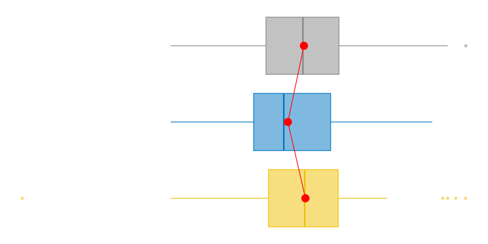

0%

8%

9%

56%

26%

Pulses above threshold

mean onset pulses above 250

5%

4%

1%

5%

5%

12%

9%

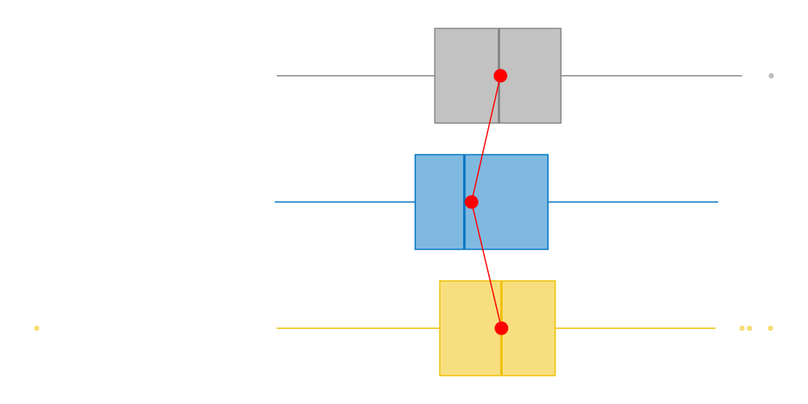

1%

8%

9%

55%

26%

Analysis based on the Akuffo et al. dataset, 2025 (https://github.com/MeLiDosProject/AkuffoEtAl_Dataset_2025)

No p-value correction was applied, as a significant difference is considered the more undesirable outcome, and should thus not be penalized

<sup>1</sup> Reduced model complexities are indicated by missing random effects